# Las enfermedades desatendidas en la era de la transición epidemiológica

Análisis de la mortalidad para el período 2004-2018

Mg. Hernan Hernandez

Epidemiología. Licenciatura en Nutrición  
hernan.hernandez@uner.edu.ar

## ¿Que son las enfermedades desatendidas?

Las ETD comprenden un grupo de **entidades nosológicas** que se distinguen por estar directamente relacionadas con **malas condiciones de vida** (residentes de zonas rurales remotas, barrios marginales, grupos étnicos relegados o zonas de conflicto), con acceso inadecuado a los servicios de salud, la educación, al agua potable y al saneamiento básico, y con ambientes tropicales (WHO (2010), OPS (2016), WHO (2017), OMS (2013)).

**Aunque la mayoría de esas enfermedades tengan tratamiento y sean curables** con medicamentos que cuestan menos de un dólar por dosis o son donados a través de la Organización Panamericana de la Salud (OPS), el perfil poblacional de los enfermos repercute poco en la agenda de prioridades de la salud pública, básicamente por su escasa incidencia en las decisiones políticas. Además, la inversión en investigación y desarrollo de nuevos y mejores medicamentos es escasa: sólo 4,4% de los nuevos productos aprobados entre 2000 y 2011 fueron para ETD, la mayoría formulaciones nuevas o combinaciones de drogas ya existentes. La ausencia de estadísticas confiables también con tribuye a su reducida visibilidad (WHO (2010), OPS (2016), Wirtz VJ (2016)).

Este grupo de enfermedades incluye:

- dengue
- rabia
- ceguera por tracoma
- úlcera de Buruli
- treponematosis
- lepra (o enfermedad de Hansen)
- enfermedad de Chagas
- leishmaniasis
- cisticercosis
- equinococosis o hidatidosis
- filariasis
- esquistosomiasis
- helmintiasis
- entre otras

### Estadísticas en Argentina

- Enfermedad de Chagas
  - En Argentina se calcula que cerca de un millón y medio de personas tienen Chagas (Msal (2022)) .
  - A 2022, en 9 provincias existe transmisión vectorial de la Enfermedad de Chagas (Msal (2022)).
  - La transmision vertical (materno infantil) es en la actualidad el principal mecanismo de transmisión en nuestro país (Msal (2022)).
  - En el período 2019-2021 para el evento Chagas congénito/vertical con diagnóstico confirmatorio, se notificó el inicio del tratamiento en el 25% para el 2019, y en el 34% para los años 2020 y 2021 (Msal (2022)).
  - Más del 80% de los casos reportados como “Chagas Agudo Congénito/Vertical” no registra el diagnóstico completo que permita confirmar o descartar la infección por T. cruzi (Msal (2022)).
- Lepra:
  - En 2022 había 343 casos de lepra en tratamiento y 142 casos nuevos registrados (1 caso cada 2,5 dias aprox.) (WHO (2024)).
- Leishmaniasis:
  - Para el año 2022, se confirmaron 163 casos de leishmanianiasis (122 cutánea, 21 mucosa, 20 Visceral), es decir 1 caso cada 2 días (Msal (2024)).
  - El 70% de los casos eran residentes del NOA (Msal (2024)).
- Equinocococis
  - En 2016, se registraron 683 casos de hidatidosis en Argentina, de los cuáles 372 fueron confirmados (Msal (2016), WHO (2024)).
  - El impacto económico se deriva de el costo de atención por paciente (estimado para 1997 en 4.500 USD), como así también por las pérdidas por decomisos de vísceras y la disminución de producción de carne, leche, lana y la fertilidad de las especies afectadas (WHO (2024)).

## Atecedentes

[figure not shown]

## Metodología

- Estudio ecológico transversal, tomando los departamentos de la Argentina como unidad de análisis. Excepto Ciudad de Buenos Aires que se la tomo como una unidad dado que la organización politica es incompatible (circunscripción electoral vs comunas).
- Período 2004-2018, ambos sexos (suma varones, mujeres y sin definición).
- Se calcularon:
  - Las razones de mortalidad estandarizadas (RME) tomando como referencia la tasas específicas por edad para ambos sexos de Argentina:
    - **Muertes esperadas** = $$\sum_{i=1}^{n} (Tasa_{\text{estándar por edad}} \times Población_{\text{por edad}})$$
    - **RME** = $$\frac{Muertes\ Observadas}{Muertes\ Esperadas} \times 100 $$
  - Las RME fueron suavizadas mediante metodo Bayesiano Local: el objetivo es “pesar” la información del área que nos interesa; es decir, ponderar los datos de mortalidad de una determinada área junto con la información sobre la distribución de la mortalidad del resto de las áreas y/o de un conjunto de ellas (áreas adyacentes)
  - Análisis Espacial e identificación de clúster: este metodo método (también llamado LISA Indicadores Locales de Asociación Espacial) descompone el índice I de Moran y verifica en cuánto contribuye cada unidad espacial a la formación del valor general, permitiendo obtener un valor de significancia para cada cluster formado por los valores similares de cada unidad espacial y sus vecinos. Estos agrupamientos o clusters de especial concentración de valores extremos de una variable se conocen también como zonas calientes/frías (hot spots/cold spots, respectivamente) según se trate de una concentración de valores especialmente altos/bajos de una variable, correspondientemente.

  Si tomamos los valores de una unidad espacial y la de sus vecinos y comparamos ambos con los valores medios (de la unidad y del vecino), podemos obtener:

  **Moran Scatterplot**

  | Bajo en X Alto en Y | Alto en X Alto en Y |
  | --- | --- |
  | **Bajo en X** **Bajo en Y** | **Alto en X** **Bajo en Y** |

## Matriz de vecindad para la Argentina por departamentos

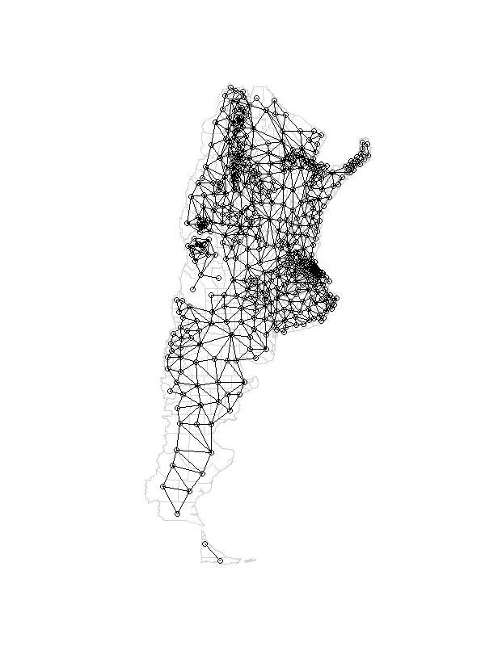

## Fuente de datos

¿Cómo se genera la información de mortalidad?

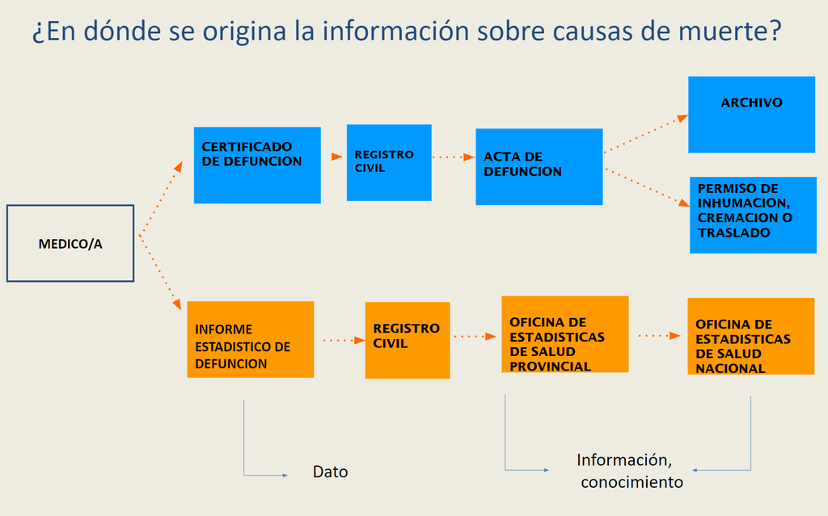

¿Qué es el Informe Estadístico de Defunción?

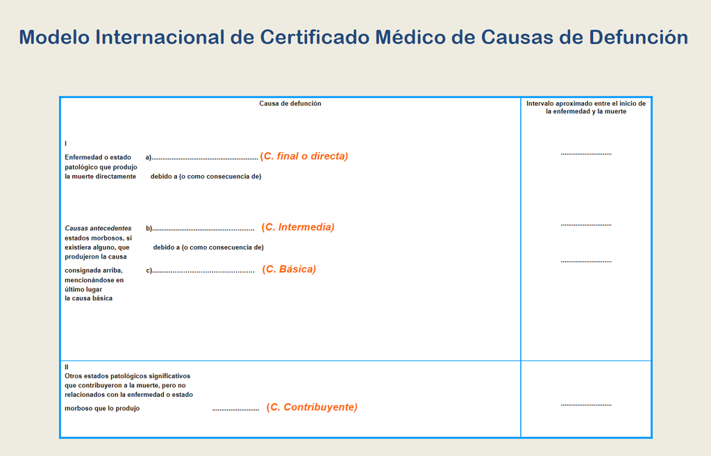

IED Mod Internacional

¿Que es la CIE?

[figure not shown]

[figure not shown]

## Resultados

### Descripción de la muestra

En el período de estudio (2004-2018), se registraron 7.190defunciones por Enfermedades Desatendidas, de las cuáles 60% (4.311) se dieron en varones y 40% (2.870) en mujeres.

### Distribución de las defunciones por edad

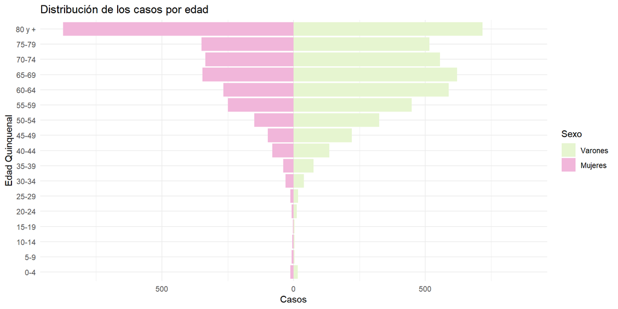

### Tasas específicas por edad

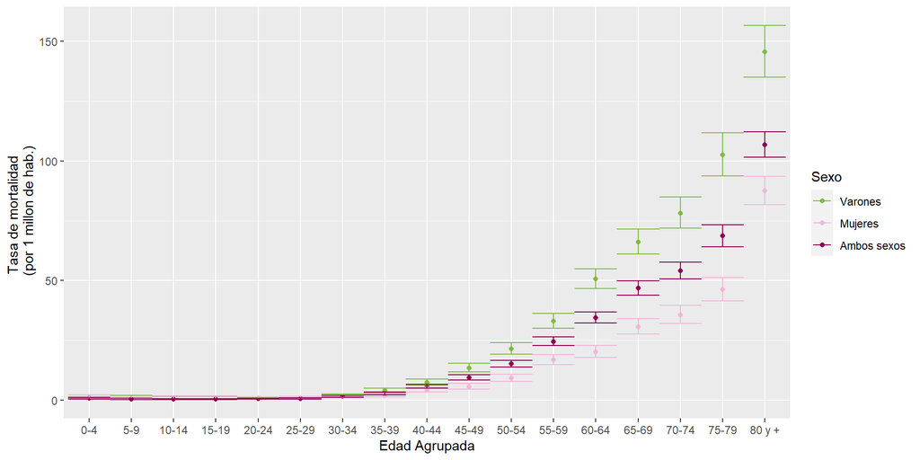

### Tasas específicas por sexo

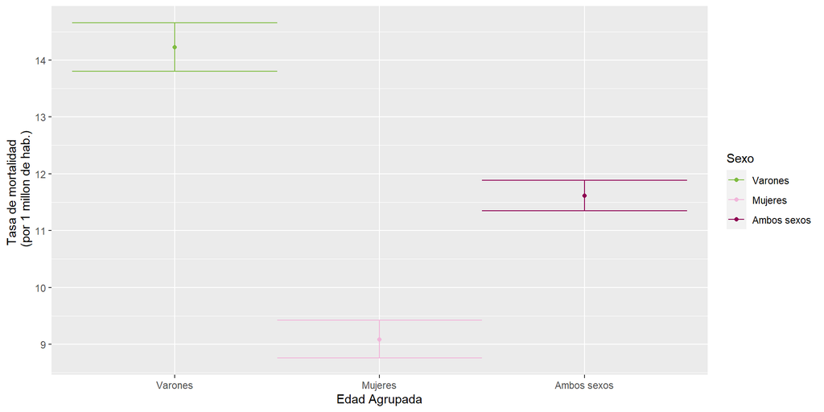

### Tasas específicas por Subtipo NTD

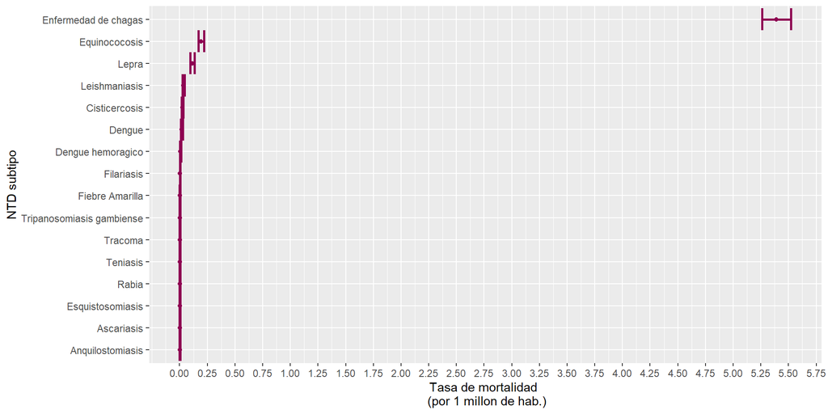

### Total NTD

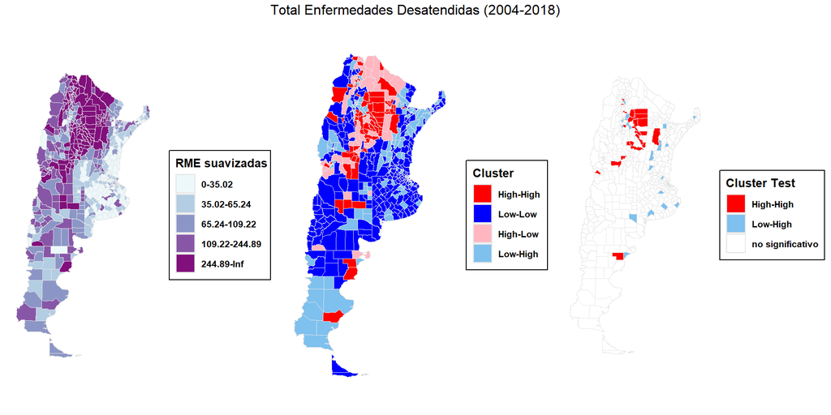

### Enfermedad de Chagas

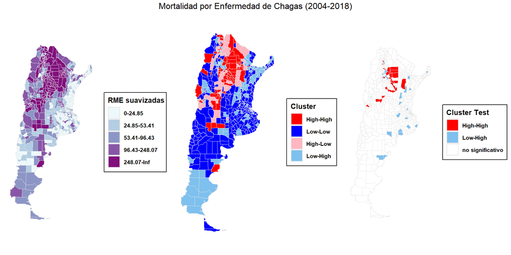

### Lepra

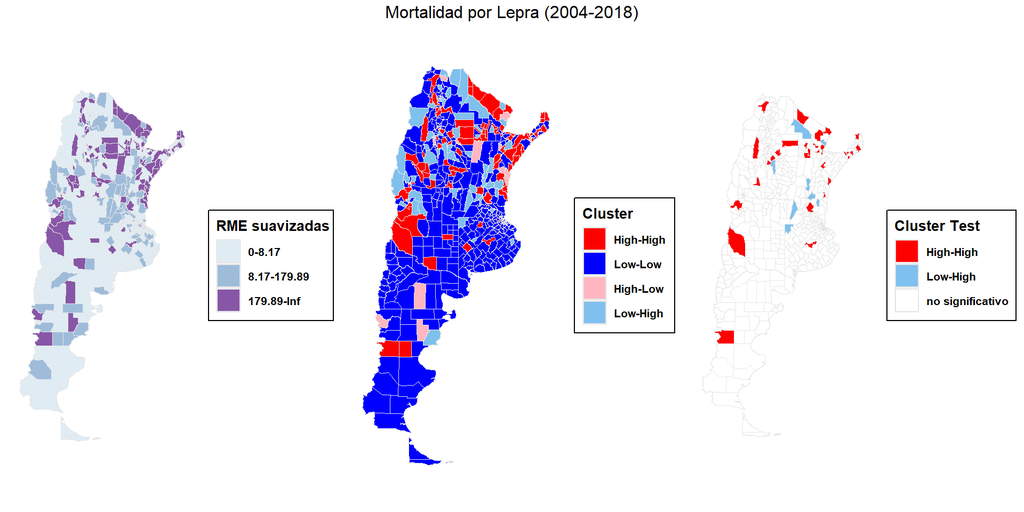

### Leishmaniasis

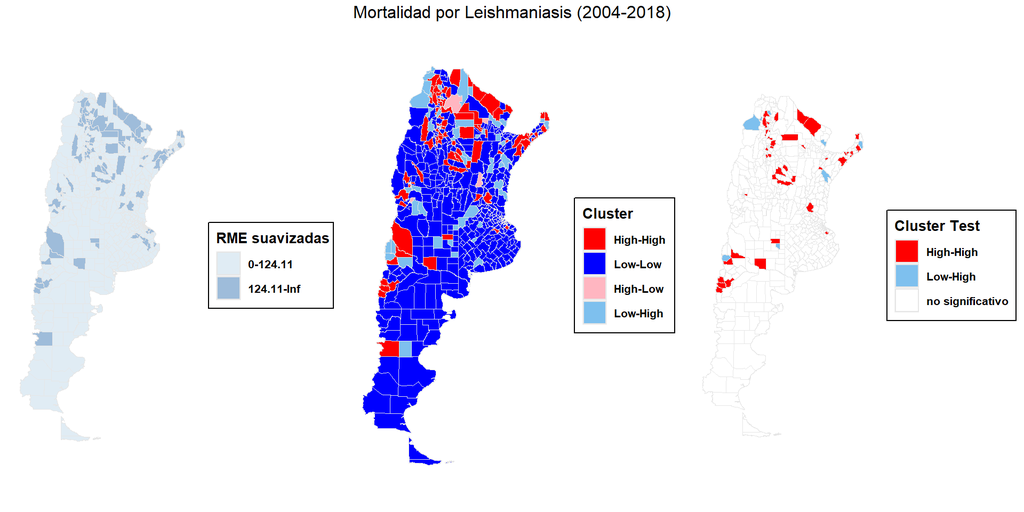

### Equinococosis

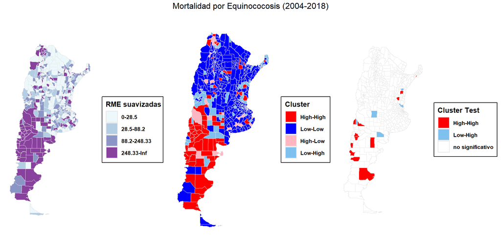

## Discusión

Los resultados de este estudio muestran una fuerte relación entre la mortalidad por ETD y el sexo y la edad. En el período estudiado, más de la mitad de los fallecidos por ETD fueron hombres:

- Otros autores lo atribuyen al hecho de que los hombres son menos propensos a buscar tratamiento temprano (Martins-Melo FR (2016), Costa de Albuquerque MA (2017)).
- Mayor tiempo de exposición en sus actividades laborales (Soares L (2014)).
- En Argentina, las mujeres refieren peores estados de salud autopercibidos que los hombres, lo que puede influir en la búsqueda de atención (Alazraqui M (2005), Estadística y Censos. (2015)).

La distribución espacial de las ETD, a excepción de la equinococosis, muestra mayor riesgo de mortalidad, en el noroeste y el noreste de Argentina:

- La asociación entre pobreza, urbanización y ETD ha sido analizada por diversos investigadores (WHO (2010) ,Martins-Melo FR (2016) , Costa de Albuquerque MA (2017), PJ. (2017)).
- En las provincias que integran estas regiones se detectan los porcentajes medios de hogares con necesidades básicas insatisfechas (que miden condiciones materiales de vida) de 25% en 2001 y de 17% en 2010, 1,8 veces más altos que el porcentaje nacional (Estadística y Censos. (2019)).
- La mayor mortalidad por equinococis en la patagonia, podría estar relacionado con el hecho de que en esta zona se concentra la producción ovina del país y a que el autoconsumo tiene valores mayores que la media nacional (WHO (2010),Msal (2012), A. A. (2019))

¿Que podemos decir desde las “dimensiones del campo de salud?

- “[…] el tratamiento de esas enfermedades no representan ganancias significativas ni para la industria farmacéutica ni para los dueños de clínicas y sanatorios. Esos tratamientos están representados por los llamados”medicamentos huérfanos” denominación que reciben al no ser rentables y por lo tanto no se los oferta en el mercado o su producción es discontinua” (Spinelli (2010)).
- La vigencia de esas enfermedades no se debe a la ausencia de conocimientos para controlarlas y erradicarlas sino a que afectan a individuos sin acceso a la ciudadanía, y que por lo tanto no tienen capacidades de colocar sus problemas en la agenda del Estado (Spinelli (2010)).
- Zabala sostiene que “[…] la enfermedad de Chagas no ha sido tan olvidada como para desaparecer de la agenda, ni tan recordada como para cortar definitivamente su ciclo de reproducción” ( Zabala (2018)).
- La trayectoria de la enfermedad de Chagas encierra una serie de paradojas que han marcado su dilatada historia ( Zabala (2018)):
  - un hito en la historia de la ciencia, y una entidad que tiende a hacerse invisible en la actual atención médica.
  - una “enfermedad olvidada”, y una constante en las agendas de las políticas públicas.
  - un relativo éxito en términos de combate del vector, y la persistencia de una realidad que favorece su desarrollo.
  - la mayor población afectada, y el grupo social menos visible en términos de identificación y organización social.
  - una enfermedad rural, pero un problema sanitario de zonas urbanas y una amenaza para países desarrollados.
  - una bandera importante del compromiso de la comunidad científica con la realidad social, y una marca de la escasa incidencia concreta de la ciencia en las condiciones de vida de las personas.
  - un área de conocimiento con un alto grado de avance, y medicamentos de alrededor de 40 años de antigüedad y limitada efectividad.

### Limitaciones

- El análisis de la mortalidad por ETD como causa básica presenta algunas limitaciones, como la subestimación y el subregistro (Martins-Melo FR (2016), Costa de Albuquerque MA (2017), H. S. A. (2009)). Si el médico que registra la defunción selecciona como causa básica las consecuencias de las ETD, la mortalidad se verá subestimada. Un estudio sobre mortalidad por enfermedad de Chagas según causas múltiples realizado en Saõ Paulo (Brasil) entre 1985 y 2006 mostró que cuando ésta es la causa básica de defunción, las causas asociadas son trastornos de la conducción/arritmias (39%) e insuficiencia cardíaca (34%) (46). En cambio, las principales causas básicas cuando la enfermedad de Chagas se registra como causa asociada son la enfermedad isquémica del corazón (22%) y enfermedad cerebrovascular (16,8%).

## Evaluación del webinar

Tu opinión sobre este webinar es muy importante!!!!

[figure not shown]

## Bibliografia

A., Asad. 2019. “Carne Ovina. Análisis de Cadena Alimentaria, 2004. Buenos Aires: Gobierno de Argentina; 2004. Disponible En: Http://Www .alimentosargentinos.gob.ar/Contenido/Revista/Html/29/29_11 _Carne_ovina.html.”

A., Hasiak Santo. 2009. “Tendência Da Mortalidade Relacionada à Paracoccidioidomicose, Estado de São Paulo, Brasil, 1985 a 2005: Estudo Usando Causas Múltiplas de Morte. Rev Panam Salud Publica. 2009;26(4):299–309.”

Alazraqui M, Fleischer N, Roux AVD. 2005. “Salud Auto-Referida y Desigualdades Sociales, Ciudad de Buenos Aires, Argentina, 2005. Cad Saude Publica. 2009;25:1990–2000.”

Costa de Albuquerque MA, Vieira LT, Dias DM. 2017. “Mortality Trends for Neglected Tropical Diseases in the State of Sergipe, Brazil, 1980-2013. Infect Dis Poverty. 2017;6(1):20–8.”

Estadística y Censos., Instituto Nacional de. 2015. “Tercera Encuesta Nacional de Factores de Riesgo Para Enfermedades No Transmisibles. 1a Ed. Buenos Aires: Ministerio de Salud; 2015.”

———. 2019. “Porcentaje de Hogares y de Población Con Necesidades Básicas Insatisfechas (NBI), Según Provincia, Total Del País, Años 2001 y 2010. Buenos Aires: INDEC; 2010. Disponible En: Https://Www.indec.gob .ar/bajarCuadroEstadistico.asp?idc=44529BECCBE3B3929DE 1D81383DF56F10050371BBB8828F6DEE64E4E6717F20455144A D3B7D0247F.”

Martins-Melo FR, Alencar CH, Ramos Jr AN. 2016. “Mortality from Neglected Tropical Diseases in Brazil, 2000-2011. Bull WHO. 2016; 94(2):103–10.”

Msal. 2012. “Guía Para El Equipo de Salud No. 11: Enfermedades Infecciosas, Hidatidosis. 1a Ed. Buenos Aires: Ministerio de Salud; 2012.”

———. 2016. “Boletín Integrado de Vigilancia. 2016, No. 341–SE 52.” https://www.argentina.gob.ar/sites/default/files/boletin_integrado_vigilancia_n341-se52.pdf.

———. 2022. “Boletin Epidemiológico Nacional. SE n° 34.”

———. 2024. “Boletín Integrado de Vigilancia. 2023, No. 680–SE 47.” https://www.argentina.gob.ar/sites/default/files/2024/04/ben_680_se_47.pdf.

OMS. 2013. “Enfermedades Tropicales Desatendidas. Prevención, Control, Eliminación y Erradicación. Informe de La Secretaría A66/20. Ginebra: OMS; 2013. (Infome A66/20.).”

OPS. 2016. “Enfermedades Infecciosas Desatendidas En Las Américas: Historias de Éxito e Innovación Para Llegar a Los Más Necesitados.”

PJ., Hotez. 2017. “Global Urbanization and the Neglected Tropical Diseases. PLoS Negl Trop Dis. 2017;11(2):e0005308.”

Soares L, Ferraz G., Abad-Franch F. 2014. “Epidemiology of Cutaneous Leishmaniasis in Central Amazonia: A Comparison of Sex-Biased Incidence Among Rural Settlers and Field Biologists. Trop Med Int Heal. 2014;19(8):988–95.”

Spinelli, H. 2010. “Las Dimensiones Del Campo de La Salud En Argentina.” https://revistas.unla.edu.ar/saludcolectiva/article/view/285.

WHO. 2010. “"Working to Overcome the Global Impact of Neglected Tropical Diseases. First WHO Report on Neglected Tropical Diseases. 1st Ed. Geneva: WHO Organization Press; 2010.”

———. 2017. “Integrating Neglected Tropical Diseases in Global Health and Development. Fourth WHO Report on Neglected Tropical Diseases. 1st Ed. Geneva: WHO Press; 2017.”

———. 2024. “The Global Health Observatory.” https://www.who.int/data/gho/data/themes/topics/leprosy-hansens-disease.

Wirtz VJ, Gray AL, Hogerzeil H V. 2016. “Essential Medicines for Universal Health Coverage. Lancet. 2016;389(10067):403–76.”

Zabala, JP. 2018. “La Enfermedad En Su Laberinto: Avances, Desafíos y Paradojas de Cien Años Del Chagas En Argentina. Salud Colect. 2012;8(supl. 1):S9–21.”